# Gregory N. Mankiw - NYT - Nov 30, 2008

1. According to Gregory N. Mankiw, the factors contributing to hold back consumption are low consumer confidence and “wait and see” behavior caused by falling house price values, shrinking 401(k) balances (due to the fall of the stock market, my addition) and increased unemployment. Yes, these factors can be interpreted in terms of a fall in $c_0$, since they reduce consumption for a given level of income $Y$.
2. Gregory N. Mankiw writes: “Keynesian theory suggests a”paradox of thrift." If all households try to save more, a short-run result could be lower aggregate demand and thus lower national income. Reduced incomes, in turn, could prevent households from reaching their new saving goals." This is exactly the type of phenomenon which we explained in lecture 8: if there is a fall in $c_0$, then output falls and saving falls as a result. Because investment is fixed and equal to $\bar{I}$, output decreases until saving equals investment again.
3. The neoclassical comment of the article is: “In normal times, a fall in consumption could be met by an increase in investment, which includes spending by businesses on plant and equipment and by households on new homes.” This is the usual logic of the Solow (1956) model, for instance. What happens in this model is that saving in fact determines investment entirely. The way this happens through market mechanisms is that the interest rate falls to equate demand and supply of capital. The cost of capital falls down to the point where firms and households want to invest enough to make productive use of all this saving. This logic is somewhat contradictory with the “paradox of thrift” logic, according to which investment is fixed or even increasing with demand (and the interest rate does not clear markets).
4. Gregory N. Mankiw is very concerned about “the long-term fiscal picture. Increased government spending may be a good short-run fix, but it would add to the budget deficit. The baby boomers are now starting to retire and claim Social Security and Medicare benefits. Any increase in the national debt will make fulfilling those unfunded promises harder in coming years.” We will talk about this potential issue during lecture 10.

# Procyclical Government spending

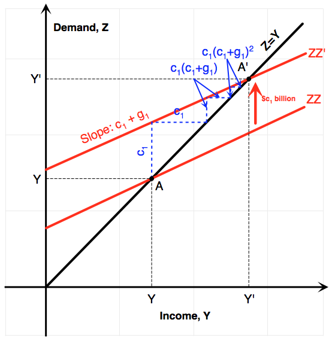

5. If $g_1+c_1>1$, then each new round of spending leads to an even greater new round of new income and new spending. Therefore, the above infinite sum is then infinite, and the tax multiplier is infinite:
   $$\begin{aligned}
   \text{Tax Multiplier} =c_1 \sum_{i=0}^{+\infty}(c_1+g_1)^i = +\infty.
   \end{aligned}$$
   Of course, this is not possible. Therefore, this just means that output cannot be demand-determined and that it is always constrained by supply (the amount of inputs there is in the economy).

# Accelerator and Automatic Stabilizer

1. We have both an automatic stabilizer as well as an accelerator effect of investment. We write, again, the total demand for goods $Z$ and then equate demand to output so that $Y=Z$:
   $$\begin{aligned}
   Y=Z &=C+\bar{I}+G\\
   Y &=c_{0}+c_{1} Y - c_1 t_0 - c_1 t_1 Y+ b_0+ b_{1}Y + G\\
   Y &=\left(c_{0}-c_{1}t_0+b_{0}+G\right)+\left(c_{1}(1-t_1)+b_1\right)Y \\
   & \Rightarrow \quad \boxed{Y=\frac{1}{1-b_{1}-c_{1}(1-t_1)}\left(c_{0}-c_{1}t_0+b_{0}+G\right)}.
   \end{aligned}$$
2. The condition is now given by:
   $$b_1 + c_1(1-t_1)<1.$$
3. If this condition isn’t satisfied, then the multiplier becomes infinite: one dollar of stimulus leads to more than 1 dollar in additional spending, etc. This leads to an infinite sum. This does not, of course, mean that GDP becomes infinite. It just means that output cannot be constrained by demand, and that the Keynesian model no longer applies. Such an economy should always be neoclassical, in other words GDP should always be limited by available factors of production (capital and labor).
4. The graph is very similar to the usual one, only that the slope is $b_1+c_1(1-t_1)$. (if asked for it in an exam, you need to provide it) The geometric sum is:
   $$1+ \left(b_1+c_1(1-t_1)\right) + \left(b_1+c_1(1-t_1)\right)^2 + ... = \frac{1}{1-b_1-c_1(1-t_1)}.$$
   (again, you will need to provide the multiplier intuition when asked for it in an exam)